# Harry Potter Episode 8 - Weasleys’ cars - K-means cluster analysis

```r
library(tidyverse)  # data wrangling
library(cluster)    # clustering
library(factoextra) # clustering and visualization
library(gridExtra) # arranging plots
```

## Data pre-processing

### Load data

```r
data <- read.delim("weasley_cars.txt")

head(data)
```

|  | car_brands | horsepower | engine | airbags | turning_radius |
| --- | --- | --- | --- | --- | --- |
| 1 | Dodge | 7.2 | 113 | 65 | 21.0 |
| 2 | Ferrari | 2.2 | 56 | 57 | 11.3 |
| 3 | Fiat | 6.0 | 115 | 66 | 18.0 |
| 4 | Ford | 9.7 | 109 | 52 | 16.3 |
| 5 | Geely | 15.4 | 249 | 66 | 22.2 |
| 6 | Honda | 2.1 | 83 | 51 | 7.8 |

```r
rownames(data) <- data$car_brands
data <- data[,-c(1)]
```

### Scale data

Standardise or scale the data by transforming the variables so that they have a mean of zero and standard deviation of one.  
We scale the data in order to make the variables comparable.

```r
# preserve original dataset
ori <- data

data <- scale(data)
data <- data.frame(data)

head(data)
```

|  | horsepower | engine | airbags | turning_radius |
| --- | --- | --- | --- | --- |
| Dodge | -0.1350014 | -0.6930840 | -0.03730631 | -0.02476943 |
| Ferrari | -1.2829727 | -1.3770485 | -0.58999237 | -1.06038781 |
| Fiat | -0.4105145 | -0.6690853 | 0.03177945 | -0.34506377 |
| Ford | 0.4389842 | -0.7410815 | -0.93542116 | -0.52656390 |
| Geely | 1.7476714 | 0.9388312 | 0.03177945 | 0.10334831 |
| Honda | -1.3059321 | -1.0530653 | -1.00450692 | -1.43406455 |

### Computing the distance or dissimilarity between observation pairs

We can use the factoextra package to compute and visualise the distance matrix.  
The `get_dist` function is used to compute a distance matrix between the rows of a data matrix. The default distance is Euclidean.  
The `fviz_dist` function is used to visualise the distance matrix.

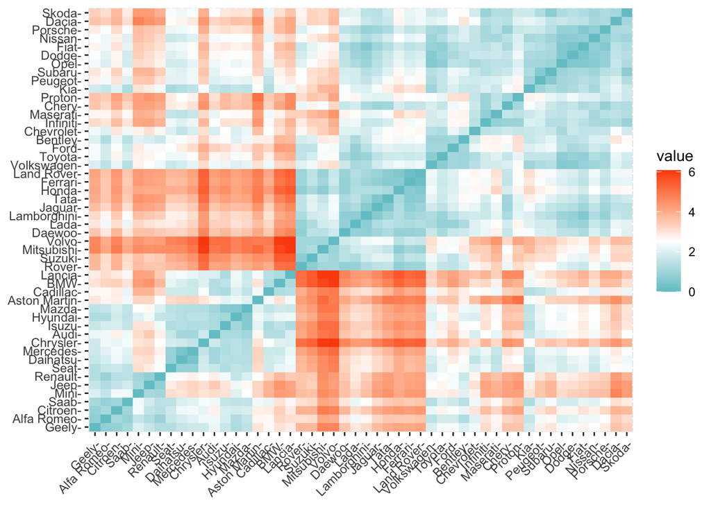

```r
distance <- get_dist(data)
fviz_dist(distance, gradient = list(low = "#00AFBB", mid = "white", high = "#FC4E07"))
```

In the heatmap, red represents dissimilarities and turquoise represents similarities.

## Perform K-Means clustering

We start by specifying the number of clusters (k). We will group the data into two clusters by specifying `centers = 2`.  
Specifying `nstart = 25` means that the algorithm will generate 25 initial configurations.

```r
k2 <- kmeans(data, centers = 2, nstart = 25)
str(k2)
```

```
## List of 9
##  $ cluster     : Named int [1:50] 1 1 1 1 2 1 2 1 2 1 ...
##   ..- attr(*, "names")= chr [1:50] "Dodge" "Ferrari" "Fiat" "Ford" ...
##  $ centers     : num [1:2, 1:4] -0.67 1.005 -0.676 1.014 -0.132 ...
##   ..- attr(*, "dimnames")=List of 2
##   .. ..$ : chr [1:2] "1" "2"
##   .. ..$ : chr [1:4] "horsepower" "engine" "airbags" "turning_radius"
##  $ totss       : num 196
##  $ withinss    : num [1:2] 56.1 46.7
##  $ tot.withinss: num 103
##  $ betweenss   : num 93.1
##  $ size        : int [1:2] 30 20
##  $ iter        : int 1
##  $ ifault      : int 0
##  - attr(*, "class")= chr "kmeans"
```

```r
k2
```

```
## K-means clustering with 2 clusters of sizes 30, 20
##
## Cluster means:
##   horsepower     engine    airbags turning_radius
## 1  -0.669956 -0.6758849 -0.1317235     -0.5646433
## 2   1.004934  1.0138274  0.1975853      0.8469650
##
## Clustering vector:
##        Dodge      Ferrari         Fiat         Ford        Geely        Honda
##            1            1            1            1            2            1
##      Hyundai     Infiniti        Isuzu       Jaguar   Alfa Romeo Aston Martin
##            2            1            2            1            2            2
##         Audi      Bentley          BMW     Cadillac        Chery    Chevrolet
##            2            1            2            2            1            1
##     Chrysler      Citroen        Dacia       Daewoo     Daihatsu         Jeep
##            2            2            1            1            2            2
##          Kia         Lada  Lamborghini       Lancia   Land Rover     Maserati
##            2            1            1            2            1            1
##        Mazda     Mercedes         Mini   Mitsubishi       Nissan         Opel
##            2            2            2            1            1            1
##      Peugeot      Porsche       Proton      Renault        Rover         Saab
##            1            1            1            2            1            2
##         Seat        Skoda        Volvo   Volkswagen       Subaru       Suzuki
##            2            1            1            1            1            1
##         Tata       Toyota
##            1            1
##
## Within cluster sum of squares by cluster:
## [1] 56.11445 46.74796
##  (between_SS / total_SS =  47.5 %)
##
## Available components:
##
## [1] "cluster"      "centers"      "totss"        "withinss"     "tot.withinss"
## [6] "betweenss"    "size"         "iter"         "ifault"
```

Based on the results, we can see that the sizes of the two clusters are 30 and 20.

## Visualising results

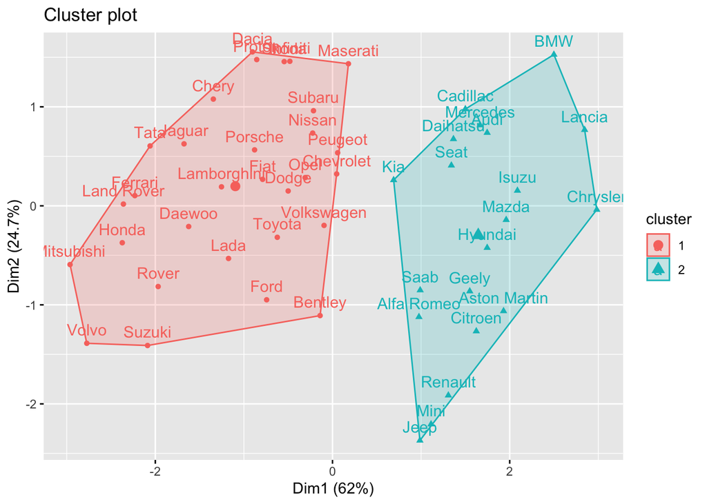

```r
fviz_cluster(k2, data = data)
```

### Let’s try different Ks

We can specify k as 3, 4 and 5 and examine the results.

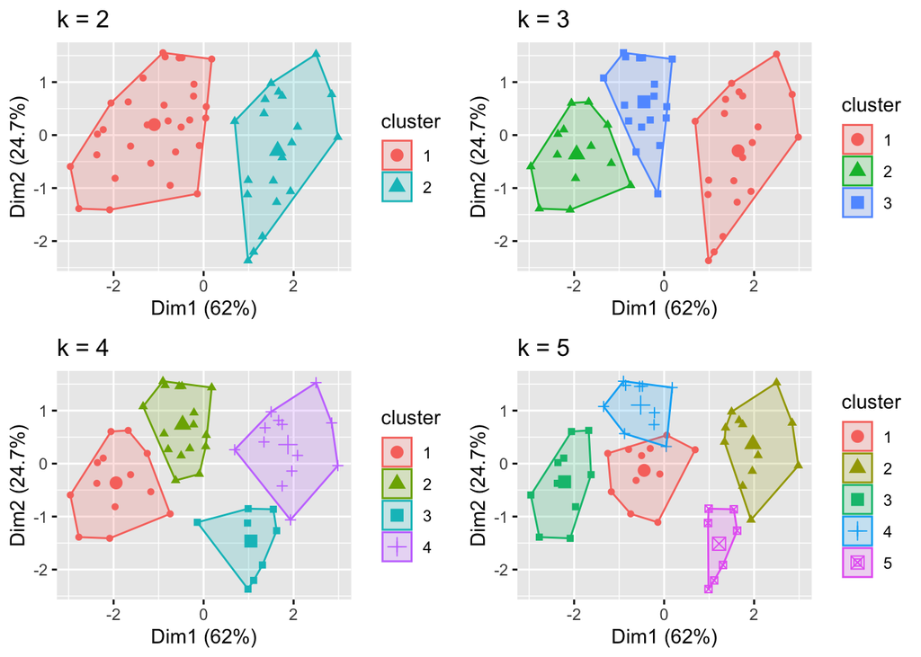

```r
k3 <- kmeans(data, centers = 3, nstart = 25)
k4 <- kmeans(data, centers = 4, nstart = 25)
k5 <- kmeans(data, centers = 5, nstart = 25)

# plots to compare
p1 <- fviz_cluster(k2, geom = "point", data = data) + ggtitle("k = 2")
p2 <- fviz_cluster(k3, geom = "point",  data = data) + ggtitle("k = 3")
p3 <- fviz_cluster(k4, geom = "point",  data = data) + ggtitle("k = 4")
p4 <- fviz_cluster(k5, geom = "point",  data = data) + ggtitle("k = 5")

grid.arrange(p1, p2, p3, p4, nrow = 2)
```

Based on the graphs, we can see whether the clusters are well separated. However, the graphs don’t tell us what the optimal number of clusters is.

## Methods for getting the optimal number of clusters

### Method 1 - Elbow

The main aim of clustering is that we want to minimise within-cluster variation. Thus, for each k, we can calculate the total within-cluster sum of square (wss) and plot the values according to the number of clusters.

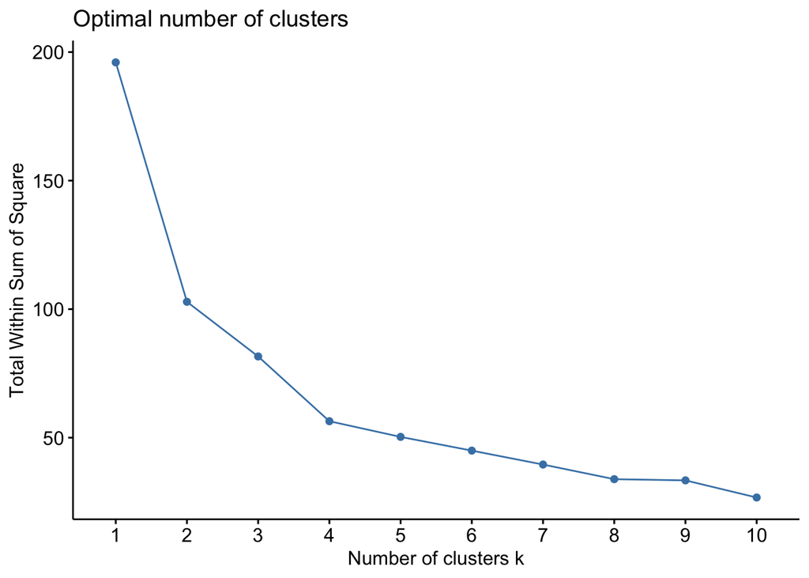

```r
set.seed(123)

# computing the within-cluster sum of square
fviz_nbclust(data, kmeans, method = "wss")
```

Based on the graph above, the ‘elbow’ (region where the line starts to bend) occurs at 4, which suggests that the optimal number of clusters is 4.

### Method 2 - Average Silhouette

The average silhouette method measures the quality of a clustering by determining how well each object lies within a cluster. The higher the average silhouette value, the better the clustering.

This method computes the average silhouette of observations for different k values. We can simply specify `method = silhouette`.

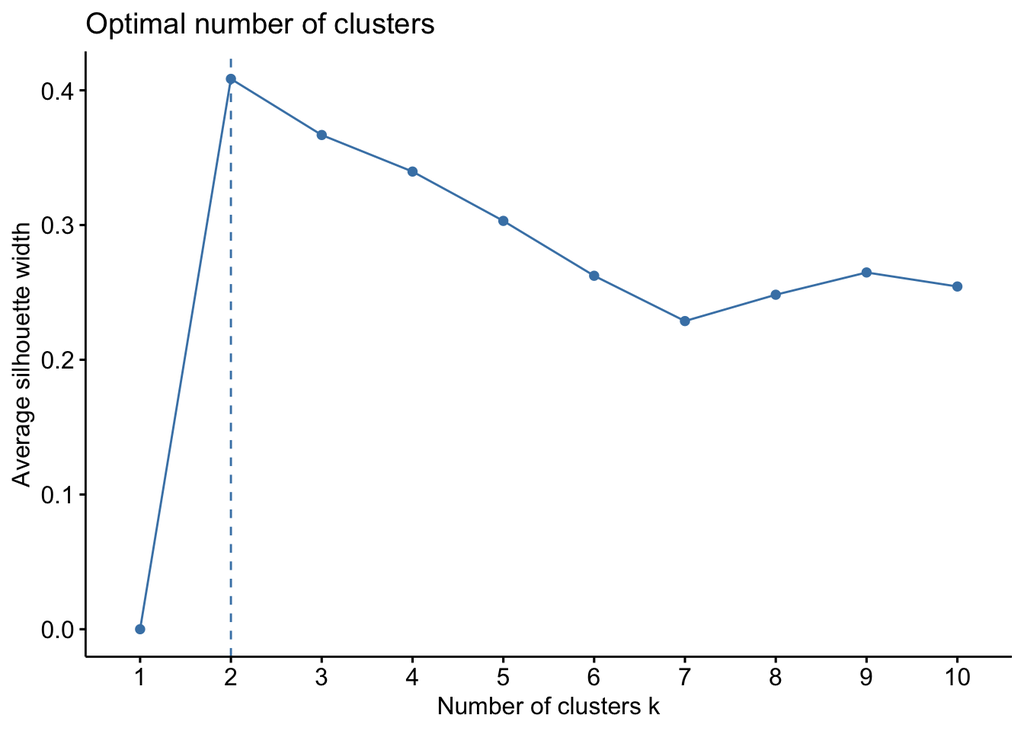

```r
fviz_nbclust(data, kmeans, method = "silhouette")
```

The graph above demonstrates that the maximum average silhouette was reached with 2 clusters. 3 clusters came in second place.

### Method 3 - Gap Statistic

This method measures how different the total intra-cluster variation is, for different k values, between observed data and reference data with a random uniform distribution (a distribution with no clustering).

```r
# calculate gap statistic
set.seed(123)
gap_stat <- clusGap(data, FUN = kmeans, nstart = 25,
                    K.max = 10, B = 50)

print(gap_stat, method = "firstmax")
```

```
## Clustering Gap statistic ["clusGap"] from call:
## clusGap(x = data, FUNcluster = kmeans, K.max = 10, B = 50, nstart = 25)
## B=50 simulated reference sets, k = 1..10; spaceH0="scaledPCA"
##  --> Number of clusters (method 'firstmax'): 4
##           logW   E.logW       gap     SE.sim
##  [1,] 3.458369 3.640154 0.1817845 0.04422857
##  [2,] 3.135112 3.372283 0.2371717 0.03559601
##  [3,] 2.977727 3.233771 0.2560446 0.03749193
##  [4,] 2.826221 3.119172 0.2929511 0.04067348
##  [5,] 2.738868 3.019965 0.2810969 0.04185469
##  [6,] 2.666967 2.930002 0.2630347 0.04105040
##  [7,] 2.609895 2.852152 0.2422572 0.04184725
##  [8,] 2.550770 2.778562 0.2277914 0.04292750
##  [9,] 2.466005 2.711752 0.2457473 0.04344197
## [10,] 2.394884 2.647595 0.2527113 0.04548446
```

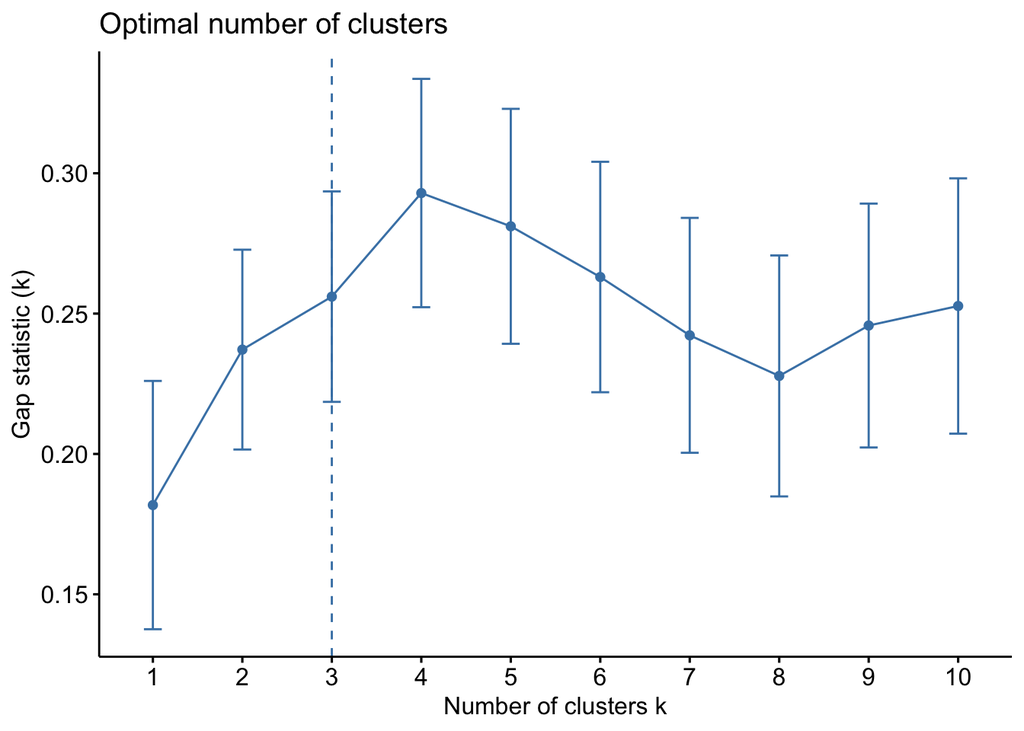

```r
fviz_gap_stat(gap_stat)
```

Based on the above graph, the optimal number of clusters is 3 clusters.

What is the optimal number of clusters?  
- Elbow method = 4 clusters  
- Average silhouette method = 2 clusters (next best = 3)  
- Gap statistic method = 3 clusters

## Final clustering with k = 3

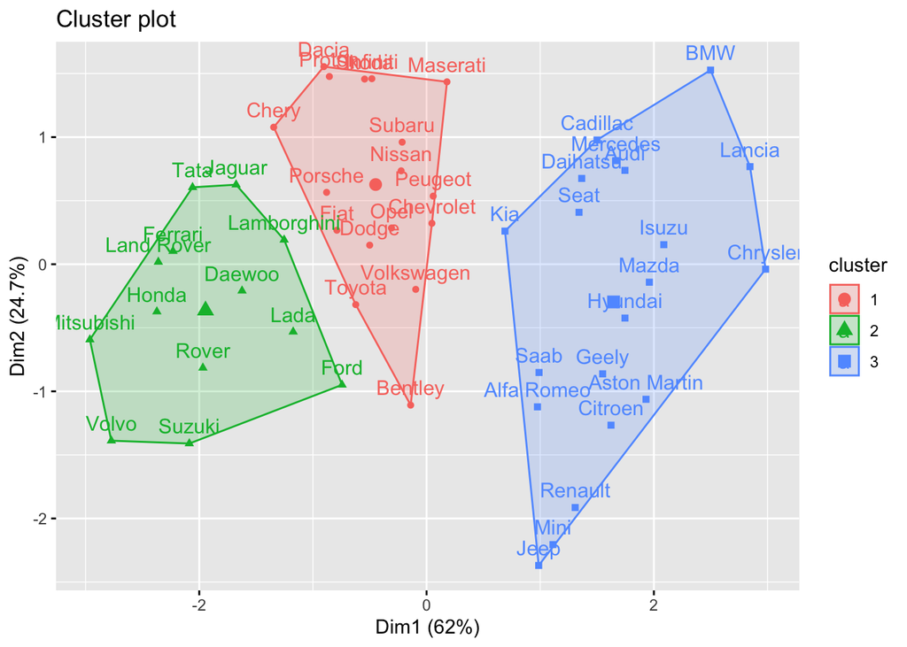

```r
# generate k-means clustering with k = 3
set.seed(123)
final <- kmeans(data, 3, nstart = 25)

fviz_cluster(final, data = data)
```

### Getting descriptive statistics for the clusters

```r
ori %>%
  mutate(Cluster = final$cluster) %>%
  group_by(Cluster) %>%
  summarise_all("mean")
```

|  | Cluster | horsepower | engine | airbags | turning_radius |
| --- | --- | --- | --- | --- | --- |
| 1 | 1 | 5.841176 | 141.88235 | 72.47059 | 18.82353 |
| 2 | 2 | 3.600000 | 78.53846 | 52.07692 | 12.17692 |
| 3 | 3 | 12.165000 | 255.25000 | 68.40000 | 29.16500 |

The table shows the average values for the four variables within each cluster.